# All_figures

L.Bystrykh, M.Belderbos

Here are all figures for the manuscript. Note that conditions for the beta distribution remain the same. First we load only those packages which are needed for the Figure 1. For some reason function melt is interfered by some packages. So we try to avoid it.

```r
library(ggplot2) #graphics
library(plot3D) #for mesh and static 3D
library(RColorBrewer) #for custom colors
library(reshape) #for melt
```

This is the version of showing beta distribution series as a surface plot for this we need a meshgrid, then we generate probability density function and all three coordinates are ready to use

```r
M<-mesh(seq(1,20,length.out=20), #series ID
        seq(0,1,length.out=20)) #beta distribution values
y <-M$y
x <-M$x
z=c()
for (i in 1:20){
  z=rbind(z,dbeta(seq(0,1,length.out=20),i,21-i))
}
```

No we plot it as static 3D. This is essentially Figure 1A

[figure not shown]

```r
surf3D(x, y, z,
       colvar = z,
       colkey = list(side = 4,plot = TRUE,length = 0.5,width =
                                            0.8,dist = 0.01, shift = 0, addlines = FALSE, col.clab = NULL, cex.clab = par("cex.lab"), side.clab
                                          = NULL, line.clab = NULL, adj.clab = NULL, font.clab = NULL),
         shade = 0.5,
       box = TRUE, bty = "b2", phi = 20, theta = 150,
       col = gg2.col(100), border = "black", facets = TRUE, clab = NULL,
       xlab = "Sizes", ylab = "Series", zlab = "Probability density",
       drawlabels = TRUE)
```

Next we make a series of heatmaps for variable beta distribution and number of clones. Here are data for the Ich heatmap

```r
Ich_series=c()
for (clones in seq(50,500, 25)){
Ich=c()
for (i in 1:20){
  values=rbeta(clones,i,21-i)
  fractions<-values/sum(values)
  selected<-fractions[fractions>=0.005]
  Ich=append(Ich,sum(selected))
}
Ich_series=cbind(Ich_series,Ich)
}
```

Now we can make a plot

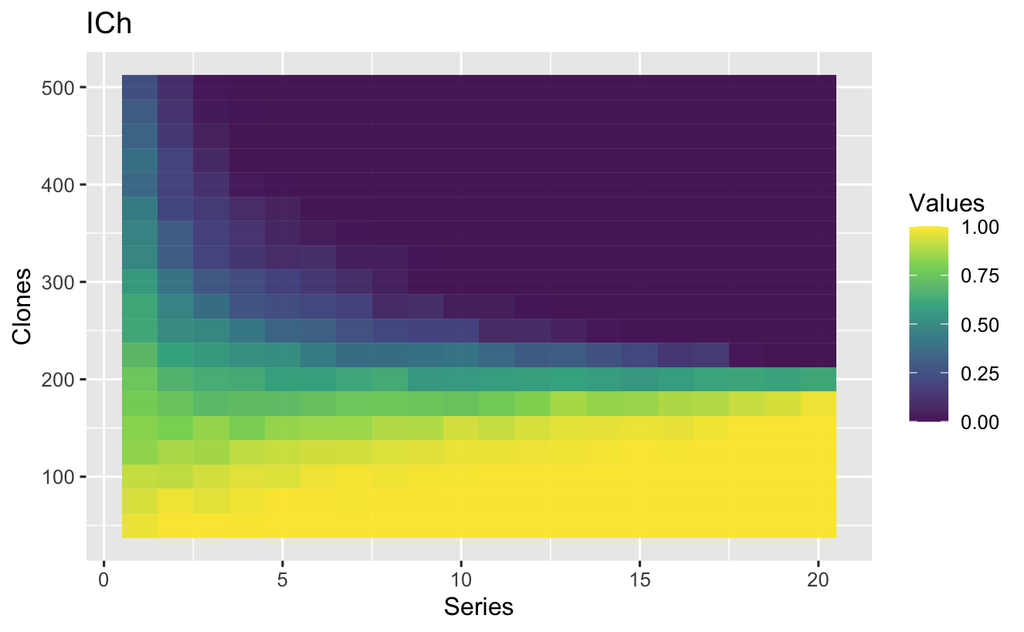

```r
#rename column names, it will be shown on the figure
colnames(Ich_series)<-seq(50,500,25) #make proper col names
coul <- colorRampPalette(brewer.pal(8, "YlGnBu"))(20)
melted<-melt(Ich_series) #or any other series down the script
colnames(melted)<-c("Skewing","Clones","Values")
ggplot(melted, aes(Skewing, Clones, fill=Values))+
  geom_tile()+
  labs(title="ICh", x="Series", y="Clones")+
  scale_fill_viridis_c(alpha=0.9)#+
```

```r
 # theme_void() #this line defines whether to show coord values or not
```

```r
library(vegan) #for Shannon and Simpson
library(reldist) #for gini index
library(OTUtable) #for pielou
# make function with switch for index selection
indexes=function(data,type){
  switch(type,
         Shannon=diversity(data, index="shannon"),
         Simpson=diversity(data, index="simpson"),
         Pielou=pielou(data),
         Gini=gini(data))
}
#make function for data series
data_series=function(kind){
  data=c()
  for (clones in seq(50,500, 25)){
    dat=c()
    for (i in 1:20){
      values=rbeta(clones,i,21-i)
      indx=indexes(values, kind)
      dat=append(dat, indx)
    }
    data=cbind(data,dat)
  }
  colnames(data)<-seq(50,500,25)
  return(data)
}
```

Now we can use it for all four indexes

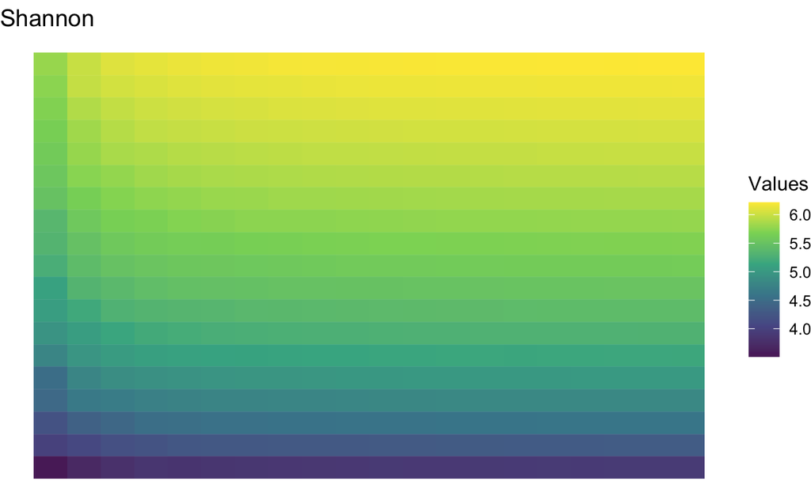

```r
#visualise any of them as below or use series above
name="Shannon" #or Simpson, Gini, Pielou
series<-data_series(kind=name)
#reformat data with melt, I cannot fix the warning
melted<- melt(series)   #or any other series down the script
colnames(melted)<-c("Skewing","Clones","Values")
ggplot(melted, aes(Skewing, Clones, fill=Values))+
  geom_tile()+
  labs(title=name, x=element_blank(), y=element_blank())+
  scale_fill_viridis_c(alpha=0.9)+
  theme_void()
```

If you want heatmap for other index, just change the name above to “Simpson”, “Gini” or “Pielou” and re-run the block. Next we move to the regression model. We will need all data for the heatmap series.

```r
#generate data series for Shannon, Simpson, Gini, Pielou indexes
Sha_series<-data_series("Shannon")
Sim_series<-data_series("Simpson")
Pie_series<-data_series("Pielou")
Gin_series<-data_series("Gini")
```

We also load the remaining packages needed for this part

```r
library(vegan) #for Shannon and Simpson
library(reldist) #for gini index
library(OTUtable) #for pielou
library(textshape) #for flatten
library(dplyr)
```

Next we convert 2D matrix data into a 1D lists

```r
#first we have to convert data from table format to a simple series
#this is called "flatten"
Ich<-as.double(flatten(as.list(Ich_series)))
Sha<-as.double(flatten(as.list(Sha_series)))
Sim<-as.double(flatten(as.list(Sim_series)))
Pie<-as.double(flatten(as.list(Pie_series)))
Gin<-as.double(flatten(as.list(Gin_series)))
```

Next we use regular linear model function to check how well used indexes predict the Ich

```r
#here we run a trivial linear model where we check whether Ich can be explained
#note: 0 means ignore intercept (there is no meaning for it)
fit<-lm(Ich~ +Sha+Sim+ Pie+ Gin)
#here we check which parameters (if any) were essential
summary(fit)
```

```
Call:
lm(formula = Ich ~ +Sha + Sim + Pie + Gin)

Residuals:
     Min       1Q   Median       3Q      Max
-0.42154 -0.08201  0.01074  0.08817  0.35065

Coefficients:
             Estimate Std. Error t value Pr(>|t|)
(Intercept) -46.31460    4.08617 -11.334   <2e-16 ***
Sha          -0.97200    0.03409 -28.511   <2e-16 ***
Sim          52.84159    4.44120  11.898   <2e-16 ***
Pie          -0.61392    1.12501  -0.546    0.586
Gin           0.19437    0.16911   1.149    0.251
---
Signif. codes:  0 ‘***’ 0.001 ‘**’ 0.01 ‘*’ 0.05 ‘.’ 0.1 ‘ ’ 1

Residual standard error: 0.1446 on 375 degrees of freedom
Multiple R-squared:  0.8812,    Adjusted R-squared:   0.88
F-statistic: 695.6 on 4 and 375 DF,  p-value: < 2.2e-16
```

```r
anova(fit)
```

```
Analysis of Variance Table

Response: Ich
           Df Sum Sq Mean Sq   F value    Pr(>F)
Sha         1 55.032  55.032 2630.5314 < 2.2e-16 ***
Sim         1  2.802   2.802  133.9373 < 2.2e-16 ***
Pie         1  0.347   0.347   16.6087  5.61e-05 ***
Gin         1  0.028   0.028    1.3211    0.2511
Residuals 375  7.845   0.021
---
Signif. codes:  0 ‘***’ 0.001 ‘**’ 0.01 ‘*’ 0.05 ‘.’ 0.1 ‘ ’ 1
```

Obviously, Ich is not the same as ano of the indexes. However it is not completely different either. R-squared value shows how well the selected model explains the Ich. We can also visualise this using two plots below

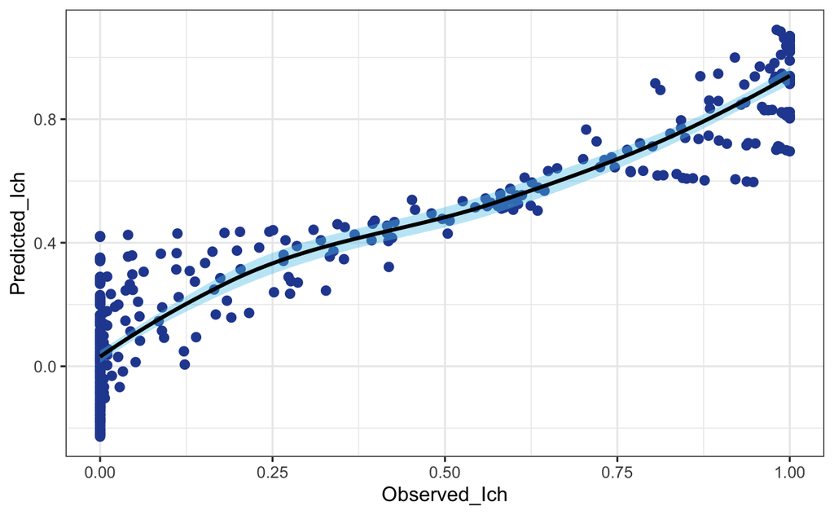

```r
####Figure 2A----
#the same in ggplot style
data<-data.frame(cbind(Ich,predict(fit)))
colnames(data)<-c("Observed_Ich","Predicted_Ich")
ggplot(data,aes(x=Observed_Ich, y=Predicted_Ich))+
  geom_point(size = 2, color = "#274ba0")+
  geom_smooth(color = "black", fill = "#59C7EB")+
  theme_bw()
```

And the last figure

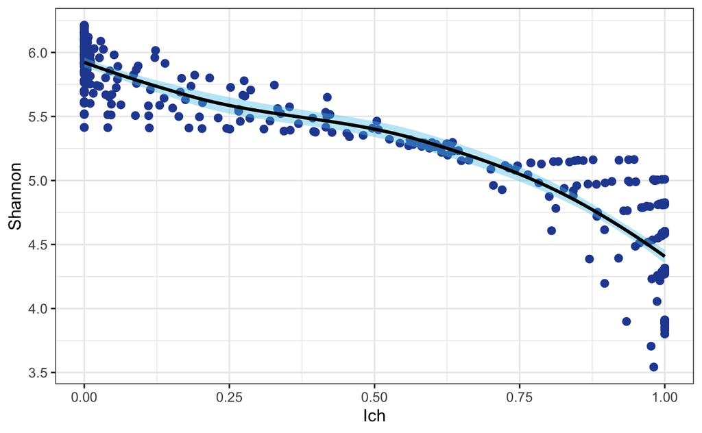

```r
data2<-data.frame(cbind(Ich,Sha))
colnames(data2)<-c("Ich","Shannon")
ggplot(data2, aes(x=Ich, y=Shannon))+
  geom_point(size = 2, color = "#274ba0")+
  geom_smooth(color = "black", fill = "#59C7EB")+
  theme_bw()
```

```r
#this were all figures for the manuscript
```

#this were all figures for the manuscript